# Manejo de Strings

Práctica Guiada

```r
# install.packages("rtweet")
library(rtweet)
library(tidyverse)
library(tm)
library(wordcloud2)
```

## Cargamos la base de tweets

```r
villa_azul_tweets <- readRDS('data/villa_azul_tweets.RDS')
```

Veamos que rango de tiempo abarcan nuestros tweets (8 días)

```r
range(villa_azul_tweets$created_at)
```

```
[1] "2020-05-18 21:17:53 UTC" "2020-05-26 20:31:10 UTC"
```

Qué tipo de variable es **created_at**??

```r
class(villa_azul_tweets$created_at)
```

```
[1] "POSIXct" "POSIXt"
```

Es un tipo de variable de tiempo expresada en zona horaria UTC).

El propio paquete `rtweet` viene con la función **ts_plot** que permite graficar la frecuencia de tweets dado un intervalo temporal.

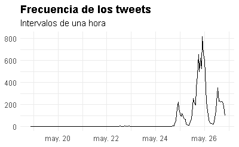

```r
villa_azul_tweets %>%
  ts_plot(by = "hours") +
  theme_minimal() +
  theme(plot.title = ggplot2::element_text(face = "bold")) +
  labs(x = NULL, y = NULL,
       title = "Frecuencia de los tweets",
       subtitle = "Intervalos de una hora")+
  scale_x_datetime()
```

## Armado del Bag of Words con `tm`

Para trabajar con grandes volumenes de texto vamos a utilizar el paquete `tm`:

- En primera instancia creamos un objeto de tipo Corpus. Utilizamos algo distinto a los conocidos vectores o dataframes, porque este es un objeto optimizado para trabajar con texto. Esto nos permite que los procesos sean mucho más eficientes, y por lo tanto trabajar con grandes volumenes de información de manera rápida

```r
myCorpus = VCorpus(VectorSource(villa_azul_tweets$text))
```

```r
expresion <- rx() %>%
  rx_find('http') %>%
 # rx_maybe('s') %>%
 # rx_maybe('://') %>%
  rx_anything_but(value = ' ')
```

Estos objetos internamente guardan una lista por cada registro, como un “documento” separado.

- Para transformar cada uno de estos documentos almacenados como una lista, vamos a usar la función **tm_map**.
- Hay una serie de transofrmaciones típicas que ya tienen funciones diseñadas (eliminacion de numeros, puntos o palabras específicas) Con el comando **getTransformations()** podemos ver las disponibles
- Para casos donde la transformacion es más específica debemos utilizar la función **content_transformer** y definir allí mismo una función.

```r
myCorpus = tm_map(myCorpus,content_transformer(function(x) str_replace_all(x, pattern = expresion, replacement = ' ')))
myCorpus = tm_map(myCorpus,content_transformer(function(x) str_remove_all(x, pattern = "[^[:alnum:][:blank:]]")))
myCorpus = tm_map(myCorpus, content_transformer(tolower))
myCorpus = tm_map(myCorpus, removeNumbers)
myCorpus = tm_map(myCorpus, removeWords, stopwords(kind = "es"))
```

3- Una vez realizadas todas las transformaciones construimos una “Document Term Matrix”. Esto es, para cada documento (en este caso, para cada tweet), un conteo de la repetición de cada una de las palabras contenidas en el total del corpus de texto. La función **inspect** aplicada a un objeto “DocumentTermMatrix” nos permite ver de que se trata la matríz construida

```r
myDTM = DocumentTermMatrix(myCorpus, control = list(
  minWordLength = 1))
inspect(myDTM)
```

```
<<DocumentTermMatrix (documents: 10537, terms: 22072)>>
Non-/sparse entries: 140792/232431872
Sparsity           : 100%
Maximal term length: 60
Weighting          : term frequency (tf)
Sample             :
      Terms
Docs   ahora avellaneda azul barrio casos chile coronavirus gente quilmes
  1887     0          0    1      0     0     0           0     0       0
  3211     0          0    1      0     0     0           0     0       0
  3787     0          0    1      1     0     1           0     0       1
  3790     0          0    1      1     0     1           0     0       1
  3799     0          0    1      1     0     1           0     0       1
  3815     0          0    1      1     0     1           0     0       1
  3821     0          0    1      1     0     1           0     0       1
  3843     0          0    1      1     0     1           0     0       1
  3859     0          0    1      1     0     1           0     0       1
  4716     1          0    1      0     0     0           1     0       1
      Terms
Docs   villa
  1887     1
  3211     1
  3787     1
  3790     1
  3799     1
  3815     1
  3821     1
  3843     1
  3859     1
  4716     2
```

**findMostFreqTerms** sirve para encontrar las palabras más frecuentes por documento o grupo de documentos. Como sólo me interesa el corpus total, tengo que modificar el INDEX para que sea el mismo en todos los documentos.

```r
vector_indices<- rep(1,nDocs(myDTM))
palabras_frecuentes <- findMostFreqTerms(
  myDTM,
  n = 25,
  INDEX = vector_indices)[[1]]
palabras_frecuentes
```

```
        villa          azul       quilmes         casos        barrio
        11067          9759          1476          1223          1130
        gente   coronavirus         ahora         chile    avellaneda
          991           823           715           690           653
     imágenes         mayra  todonoticias         covid       mendoza
          606           606           557           501           494
      vecinos   aislamiento mayrasmendoza          hace          agua
          474           458           457           450           447
    positivos           hoy    cuarentena         berni      gobierno
          435           427           403           401           391
```

Armo un dataframe con esta información y eliminos las palabras villa y azul, utilizadas para descargar los datos (logicamente son las que mas aparecen)

```r
palabras_frecuentes_tibble <- tibble(
  word = names(palabras_frecuentes),
  freq =palabras_frecuentes)
palabras_frecuentes_tibble <- palabras_frecuentes_tibble %>%
  filter(!(word  %in%  c('villa',"azul")))
```

Con el comando `wordcloud2` creo la nube de palabras

```r
wordcloud2(palabras_frecuentes_tibble)
```

[interactive chart not shown]